# Diabetes Analysis

### Introduction

The objective of this project is to use different data analysis tools to explore this diabetes dataset that originates from NIDDK (National Institute of Diabetes and Digestive and Kidney Diseases)

```r
library(moderndive)
library(ggplot2)
library(dplyr)
library(infer)
```

##Read data

```r
diabetes_raw <- read.csv('diabetes.csv')
head(diabetes_raw)
```

|  | Pregnancies | Glucose | BloodPressure | SkinThickness | Insulin | BMI | DiabetesPedigreeFunction | Age | Outcome |
| --- | --- | --- | --- | --- | --- | --- | --- | --- | --- |
| 1 | 6 | 148 | 72 | 35 | 0 | 33.6 | 0.627 | 50 | 1 |
| 2 | 1 | 85 | 66 | 29 | 0 | 26.6 | 0.351 | 31 | 0 |
| 3 | 8 | 183 | 64 | 0 | 0 | 23.3 | 0.672 | 32 | 1 |
| 4 | 1 | 89 | 66 | 23 | 94 | 28.1 | 0.167 | 21 | 0 |
| 5 | 0 | 137 | 40 | 35 | 168 | 43.1 | 2.288 | 33 | 1 |
| 6 | 5 | 116 | 74 | 0 | 0 | 25.6 | 0.201 | 30 | 0 |

```r
clean_diabetes <- diabetes_raw %>%
  filter(Glucose != 0 & BloodPressure != 0 & BMI != 0 )
```

##Glucose VS Diabetes #Data visualization Patients with diabetes are correlated with higher blood glucose level. So for our dataset, we would also make the hypothesis that diabetic patients have a higher blood glucose level, and our null hypothesis is that there’s no difference in the blood glucose level between diabetic and non-diabetic patients. Let us see if this is true for our dataset:

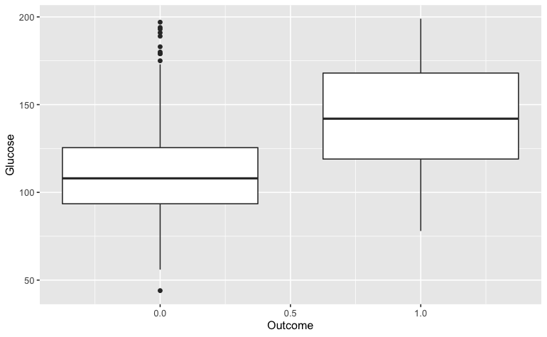

```r
ggplot(data = clean_diabetes, aes(x = Outcome, y = Glucose, group = cut_width(Outcome, 1)))+ geom_boxplot()
```

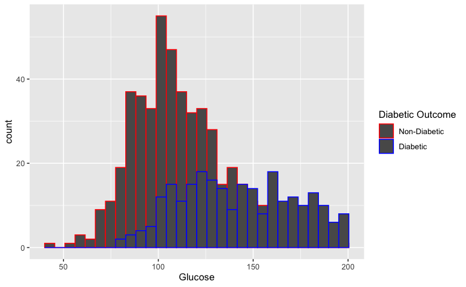

```r
ggplot(data = clean_diabetes, aes(x = Glucose, color = cut_width(Outcome, 1))) +
  geom_histogram(position="identity") +
  scale_color_manual(name="Diabetic Outcome", labels = c("Non-Diabetic","Diabetic"), values=c("red","blue"))
```

From this plot, we can see that there is a clear separation of glucose level between diabetic and non-diabetics, where diabetic patients have a higher glucose level than non-diabetic patients. Or if we look at the histogram, non-diabetic patients seems to be more concentrated at 100 level, where diabetic patients seems to be more spreadout at the right side of the chart, and most are above 100.

```r
glucose_outcome_model <- lm(data = clean_diabetes, Glucose ~ Outcome)
get_regression_table(glucose_outcome_model)
```

| term | estimate | std_error | statistic | p_value | lower_ci | upper_ci |
| --- | --- | --- | --- | --- | --- | --- |
| intercept | 111.017 | 1.232 | 90.107 | 0 | 108.598 | 113.436 |
| Outcome | 31.594 | 2.101 | 15.038 | 0 | 27.469 | 35.718 |

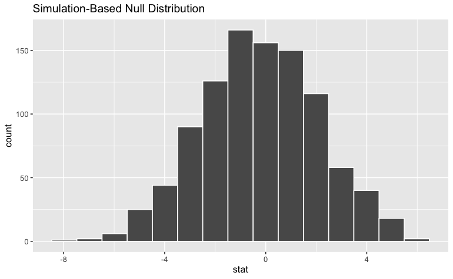

```r
clean_diabetes_outcome <- clean_diabetes
clean_diabetes_outcome$Outcome[clean_diabetes_outcome$Outcome == 1] <- "Diabetic"
clean_diabetes_outcome$Outcome[clean_diabetes_outcome$Outcome == 0] <- "Non-Diabetic"

null_distribution_diabetes <- clean_diabetes_outcome %>%
  specify(formula = Glucose ~ Outcome) %>%
  hypothesize(null = "independence") %>%
  generate(reps = 1000, type = "permute") %>%
  calculate(stat = "diff in means", order = c("Diabetic", "Non-Diabetic"))

visualise(null_distribution_diabetes)
```

here i’m trying to conduct a hypothesis test on this data set through generating a null distribution and use a histogram to visualize how the simulation based null distribution looks like

```r
obs_diff_means <- clean_diabetes_outcome %>%
  specify(formula = Glucose ~ Outcome) %>%
  calculate(stat = "diff in means", order = c("Diabetic", "Non-Diabetic"))
obs_diff_means
```

```
Response: Glucose (numeric)
Explanatory: Outcome (factor)
```

| stat |
| --- |
| 31.5936 |

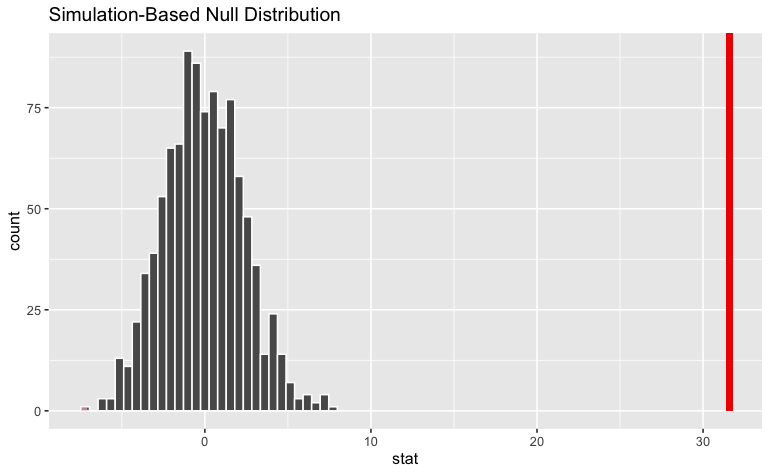

```r
visualize(null_distribution_diabetes, bins = 30) +
  shade_p_value(obs_stat = obs_diff_means, direction = "both")
```

We can visualize the p-value in the null distribution through this method by comparing it to the observed difference in mean, which is around 31. We do this through shade_p_value(). We can see that the slope falls at the very right of null distribution, so we have a very small p-value. Let’s make sure what the exact p-value is here:

```r
null_distribution_diabetes %>%
  get_p_value(obs_stat = obs_diff_means, direction = "both")
```

| p_value |
| --- |
| 0 |

the p-value here is so small that’s the software can’t show the number. It’s not 0, but it’s very small. So based on this, we can reject the null hypothesis. We have a significant evidence to suggest that there’s a significant relationship between glucose and whether or not the person is diabetic.

#Glucose VS BMI BMI is also a variable that’s closely correlated to diabetes:

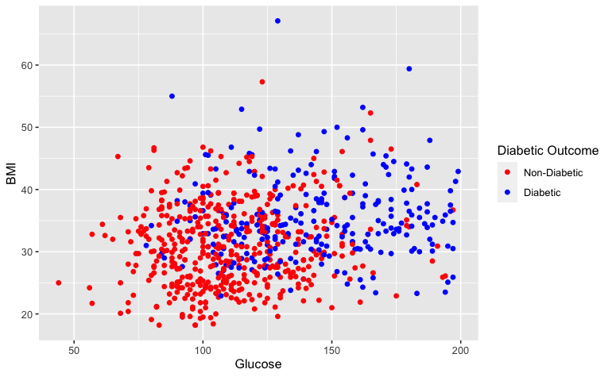

```r
ggplot(data = clean_diabetes, aes(x = Glucose, y = BMI, color=factor(Outcome))) +
  geom_point() +
  scale_color_manual(name="Diabetic Outcome", labels = c("Non-Diabetic","Diabetic"), values=c("red","blue"))
```